# Gerrymandering in Alabama

Gus Howard

2025-05-20

# Study metadata

Key Words: Compactness, Gerrymandering, Convex hull Subject: Social and Behavioral Sciences: Geography: Geographic Information Sciences Date: 02-18-2025 Spatial Coverage: Alabama Spatial resolution: Census Block Groups Spatial reference System: EPSG: 4269 NAD 1983 GCS Temporal Coverage: 2020-2024 Temporal Resolution: Decennial Census

# Study design

This is an original study based on literature on gerrymandering metrics.

It is an exploratory study to evaluate the usefulness of a new gerrymandering metric based on the convex hull of a congressional district and the representativeness inside the convex hull compared to the congressional district.

## Computational environment

I plan on using package the following packages: tidyverse - for general data manipulation, here - for file location, sf - for analyzing spatial data, tmap - to represent spatial data, tidycensus - for gathering census data, and kableExtra with R version 4.4.2.

```r
groundhog.day <- "2025-03-08"

# this replaces any library() or require() calls
groundhog.library(packages, groundhog.day)
```

[output not shown]

```r
# you may need to install a correct version of R
# you may need to respond OK in the console to permit groundhog to install packages
# you may need to restart R and rerun this code to load installed packages
# In RStudio, restart r with Session -> Restart Session

# record the R processing environment
# alternatively, use devtools::session_info() for better results
# writeLines(
#   capture.output(sessionInfo()),
#   here("procedure", "environment", paste0("r-environment-", Sys.Date(), ".txt"))
# )

# save package citations
knitr::write_bib(c(packages, "base"), file = here("software.bib"))

# set up default knitr parameters
# https://yihui.org/knitr/options/
knitr::opts_chunk$set(
  echo = FALSE, # Run code, show outputs (don't show code)
  fig.retina = 4,
  fig.width = 8,
  fig.path = paste0(here("results", "figures"), "/")
)
```

## Data Sources

### Precincts

- `Title`: Voting Precincts 2020
- `Abstract`: Alabama voting data for 2020 elections by precinct.
- `Spatial Coverage`: Alabama
- `Spatial Resolution`: Voting precincts
- `Spatial Reference System`: EPSG 4269 NAD 1983 geographic coordinate system
- `Temporal Coverage`: precincts used for tabulating the 2020 census
- `Temporal Resolution`: annual election

Precincts 2020 - VTDST20: Voting district ID - GEOID20: Unique geographic ID - G20PRETRU: Total vote for trump in 2020 - G20PREBID: Total votes for Biden in 2020

### Districts

- `Title`: Voting Districts 2020
- `Abstract`: Congressional Districts
- `Spatial Coverage`: Alabama
- `Spatial Resolution`: US Congressional Districts
- `Spatial Reference System`: EPSG 3857 WGS 1984 Web Mercator projection
- `Temporal Coverage`: Districts approved in 2023 for 2024
- `Temporal Resolution`: annual election

US Congressional districts - DISTRICT: US Congressional District Number - POPULATION: Total Population (2020 census) - WHITE: total white population (2020 census) - BLACK: total Black or African American population (2020 census)

### Block Groups

- `Title`: Block Groups 2020
- `Abstract`: Vector polygon geopackage layer of 2020 Census Block Groups and demographic data
- `Spatial Coverage`: Alabama
- `Spatial Resolution`: Census Block Groups
- `Spatial Reference System`: EPSG 4269 NAD 1983 geographic coordinate system
- `Temporal Coverage`: 2020 Census
- `Temporal Resolution`: 2020 Census Block Groups
- GEOID: code to uniquely identify tracts
- P4_001N: Total Population, 18 years or older
- P4_006N: Total: Not Hispanic or Latino, Population of one race, Black or African American alone, 18 years or older
- P5_003N:Total institutionalized population in correctional facilities for adults, 18 years or older

transform block groups to WGS 1984

Map the districts

[output not shown]

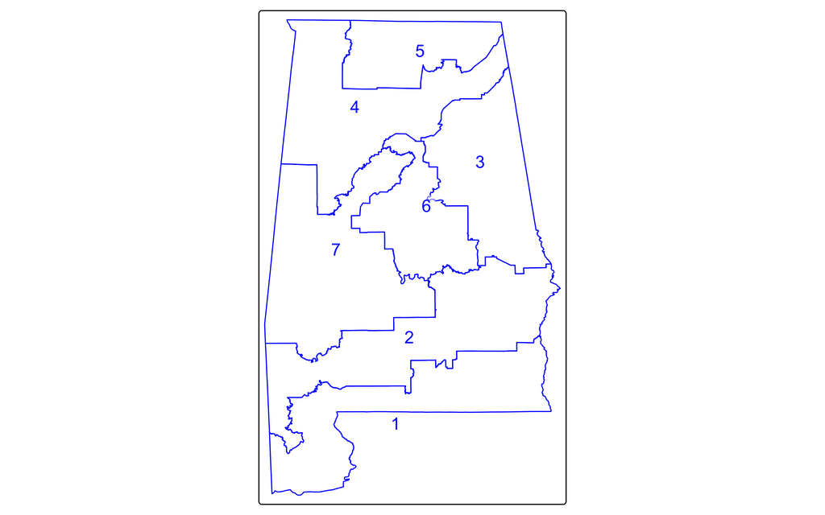

## Prior observations

At the time of this study pre-registration, the author had little prior knowledge of the geography of the study region with regards to the gerrymandering phenomena to be studied. This study is related to one prior study by the author, in which the compactness of Alabama’s voting districts was calculated, as well as voting statistics in relation to race.

## Bias and threats to validity

MAUP and Scale may affect these results.

Given the boundaries of this study are essential to the analysis, the Modifiable Areal Unit problem will certainly have relevant impacts. The constantly changing boundaries of voting precincts can impact both visualization of the data, as well as the analysis of it. The scale and shape of the units used has the potential to alter the data used in the study.

# Data Transformations

### Calculate Percent Black

| X | name | label |
| --- | --- | --- |
| 151 | P3_004N | !!Total:!!Population of one race:!!Black or African American alone |
| 158 | P3_011N | !!Total:!!Population of two or more races:!!Population of two races:!!White; Black or African American |
| 163 | P3_016N | !!Total:!!Population of two or more races:!!Population of two races:!!Black or African American; American Indian and Alaska Native |
| 164 | P3_017N | !!Total:!!Population of two or more races:!!Population of two races:!!Black or African American; Asian |
| 165 | P3_018N | !!Total:!!Population of two or more races:!!Population of two races:!!Black or African American; Native Hawaiian and Other Pacific Islander |
| 166 | P3_019N | !!Total:!!Population of two or more races:!!Population of two races:!!Black or African American; Some Other Race |
| 174 | P3_027N | !!Total:!!Population of two or more races:!!Population of three races:!!White; Black or African American; American Indian and Alaska Native |
| 175 | P3_028N | !!Total:!!Population of two or more races:!!Population of three races:!!White; Black or African American; Asian |
| 176 | P3_029N | !!Total:!!Population of two or more races:!!Population of three races:!!White; Black or African American; Native Hawaiian and Other Pacific Islander |
| 177 | P3_030N | !!Total:!!Population of two or more races:!!Population of three races:!!White; Black or African American; Some Other Race |
| 184 | P3_037N | !!Total:!!Population of two or more races:!!Population of three races:!!Black or African American; American Indian and Alaska Native; Asian |
| 185 | P3_038N | !!Total:!!Population of two or more races:!!Population of three races:!!Black or African American; American Indian and Alaska Native; Native Hawaiian and Other Pacific Islander |
| 186 | P3_039N | !!Total:!!Population of two or more races:!!Population of three races:!!Black or African American; American Indian and Alaska Native; Some Other Race |
| 187 | P3_040N | !!Total:!!Population of two or more races:!!Population of three races:!!Black or African American; Asian; Native Hawaiian and Other Pacific Islander |
| 188 | P3_041N | !!Total:!!Population of two or more races:!!Population of three races:!!Black or African American; Asian; Some Other Race |
| 189 | P3_042N | !!Total:!!Population of two or more races:!!Population of three races:!!Black or African American; Native Hawaiian and Other Pacific Islander; Some Other Race |
| 195 | P3_048N | !!Total:!!Population of two or more races:!!Population of four races:!!White; Black or African American; American Indian and Alaska Native; Asian |
| 196 | P3_049N | !!Total:!!Population of two or more races:!!Population of four races:!!White; Black or African American; American Indian and Alaska Native; Native Hawaiian and Other Pacific Islander |
| 197 | P3_050N | !!Total:!!Population of two or more races:!!Population of four races:!!White; Black or African American; American Indian and Alaska Native; Some Other Race |
| 198 | P3_051N | !!Total:!!Population of two or more races:!!Population of four races:!!White; Black or African American; Asian; Native Hawaiian and Other Pacific Islander |
| 199 | P3_052N | !!Total:!!Population of two or more races:!!Population of four races:!!White; Black or African American; Asian; Some Other Race |
| 200 | P3_053N | !!Total:!!Population of two or more races:!!Population of four races:!!White; Black or African American; Native Hawaiian and Other Pacific Islander; Some Other Race |
| 205 | P3_058N | !!Total:!!Population of two or more races:!!Population of four races:!!Black or African American; American Indian and Alaska Native; Asian; Native Hawaiian and Other Pacific Islander |
| 206 | P3_059N | !!Total:!!Population of two or more races:!!Population of four races:!!Black or African American; American Indian and Alaska Native; Asian; Some Other Race |
| 207 | P3_060N | !!Total:!!Population of two or more races:!!Population of four races:!!Black or African American; American Indian and Alaska Native; Native Hawaiian and Other Pacific Islander; Some Other Race |
| 208 | P3_061N | !!Total:!!Population of two or more races:!!Population of four races:!!Black or African American; Asian; Native Hawaiian and Other Pacific Islander; Some Other Race |
| 211 | P3_064N | !!Total:!!Population of two or more races:!!Population of five races:!!White; Black or African American; American Indian and Alaska Native; Asian; Native Hawaiian and Other Pacific Islander |
| 212 | P3_065N | !!Total:!!Population of two or more races:!!Population of five races:!!White; Black or African American; American Indian and Alaska Native; Asian; Some Other Race |
| 213 | P3_066N | !!Total:!!Population of two or more races:!!Population of five races:!!White; Black or African American; American Indian and Alaska Native; Native Hawaiian and Other Pacific Islander; Some Other Race |
| 214 | P3_067N | !!Total:!!Population of two or more races:!!Population of five races:!!White; Black or African American; Asian; Native Hawaiian and Other Pacific Islander; Some Other Race |
| 216 | P3_069N | !!Total:!!Population of two or more races:!!Population of five races:!!Black or African American; American Indian and Alaska Native; Asian; Native Hawaiian and Other Pacific Islander; Some Other Race |
| 218 | P3_071N | !!Total:!!Population of two or more races:!!Population of six races:!!White; Black or African American; American Indian and Alaska Native; Asian; Native Hawaiian and Other Pacific Islander; Some Other… |

Save the results as `blockgroups_calc.gpkg`

Map the percentage of the population 18 or over that is Black or African American.

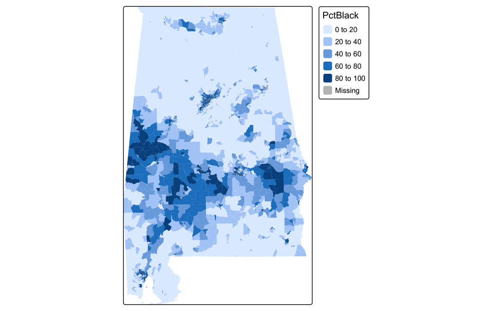

## Analysis

First, this is the total population, but we should care more about the voting age population. Second, we may want to categorize and calculate `BLACK` differently from the state of Alabama.

Spatial indices in R: https://r-spatial.org/r/2017/06/22/spatial-index.html

Report results. We find very similar percentages of Black or African American people.

| DISTRICT | POPULATION | WHITE | BLACK | bgTotal | bgBlack | pctBlackbg |
| --- | --- | --- | --- | --- | --- | --- |
| 1 | 717754 | 527330 | 116462 | 556559.0 | 90288.76 | 16.2 |
| 2 | 717754 | 303461 | 353228 | 559640.2 | 272078.98 | 48.6 |
| 3 | 717754 | 508080 | 146376 | 564183.0 | 116778.64 | 20.7 |
| 4 | 717754 | 585183 | 49721 | 558441.9 | 42522.09 | 7.6 |
| 5 | 717754 | 495427 | 126226 | 560573.5 | 102750.67 | 18.3 |
| 6 | 717755 | 517634 | 125785 | 552556.9 | 96865.75 | 17.5 |
| 7 | 717754 | 283337 | 378364 | 564941.7 | 293014.56 | 51.9 |

Join convex hull estimates to Districts with blockgroup estimates.

# Results

### Correlation matrix and small plots for gerrymandering indicators

|  | pctBlackbg | diffPct | absdiffPct | compact_shp | compact_hull | compact_circ |
| --- | --- | --- | --- | --- | --- | --- |
| pctBlackbg | 1.0000000 | 0.8656916 | 0.2755931 | -0.2814174 | -0.1247704 | 0.0389629 |
| diffPct | 0.8656916 | 1.0000000 | -0.0363323 | 0.1128061 | 0.1850875 | 0.1185339 |
| absdiffPct | 0.2755931 | -0.0363323 | 1.0000000 | -0.6801495 | -0.5295192 | 0.2456776 |
| compact_shp | -0.2814174 | 0.1128061 | -0.6801495 | 1.0000000 | 0.9557498 | 0.4197650 |
| compact_hull | -0.1247704 | 0.1850875 | -0.5295192 | 0.9557498 | 1.0000000 | 0.5039445 |
| compact_circ | 0.0389629 | 0.1185339 | 0.2456776 | 0.4197650 | 0.5039445 | 1.0000000 |

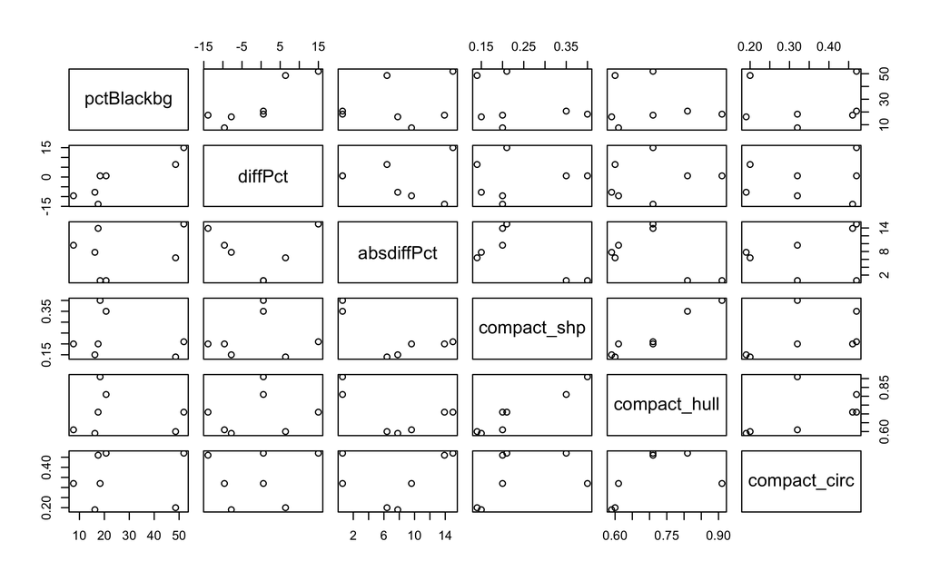

### Plot representational difference against compactness

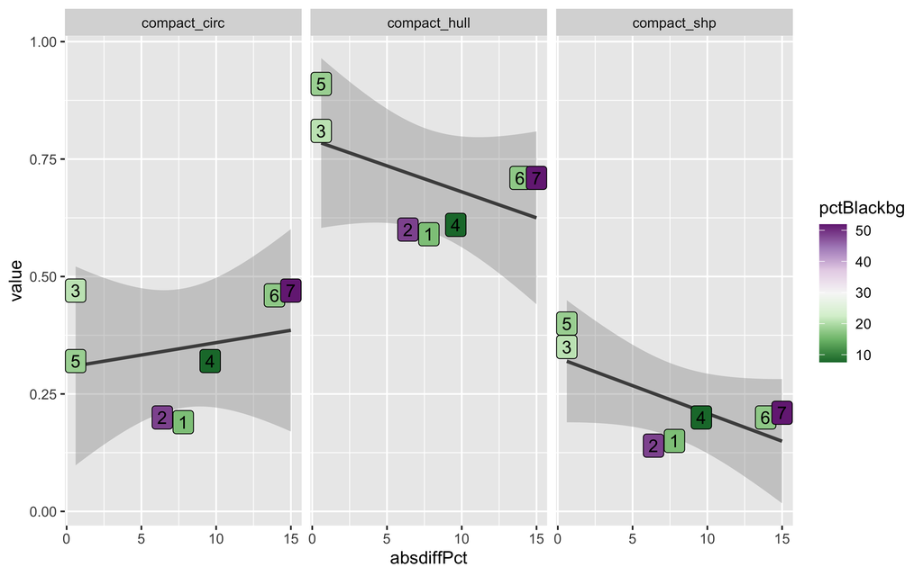

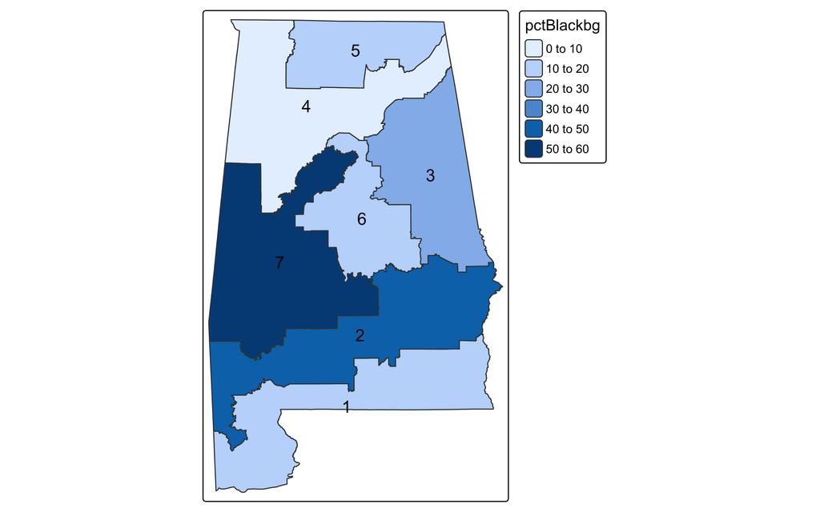

# Discussion

This report is based upon the template for Reproducible and Replicable Research in Human-Environment and Geographical Sciences, DOI: 10.17605/OSF.IO/W29MQ